# Airlines - SDS2 Project

## Posterior distribution

The posterior distribution for $\theta$ is $\theta|y \sim \Gamma(634,26)$ and the conditional distribution of $\tilde{y}$ (the number of fatal accidents in 2002) is $Poisson(\theta)$.

So to simulate values of $\tilde{y}$ all we need to do is first generate a realized value form the posterior distribution of $\theta$ as the mean. Iterating this process will generate values of $\tilde{y}$ from the posterior predictive distribution. What we are doing here is integrating numerically, using simulation, over the posterior distrobution in $\theta$. We can simulate this easily in R.

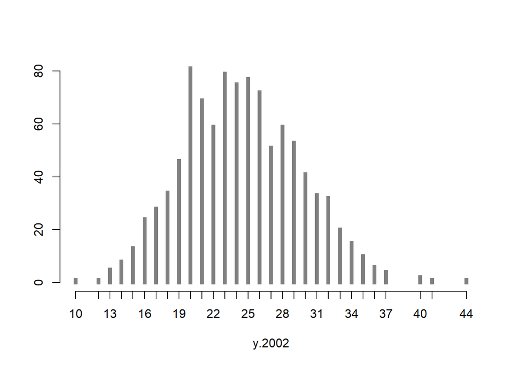

```r
theta <- rgamma(1000, 634, 26 )
y.2002 <- rpois(1000,theta)
#hist( y.2002 )
plot( table(y.2002), type="h", lwd=5, lend=2, col=gray(0.5), bty="n", ylab="" )
```

We can specify the model in R using the package rJags.

```r
a1.par <- c("mu","fatal[27]")

a1.ini <- list(list( mu=22 ),
              list( mu=23 ),
              list( mu=24 ) )

a1.dat <- list( fatal = c(airline$fatal,NA), I=27 )

# Model compilation and burn-in
a1.mod <- jags.model( file = "a1.jag",
                    data = a1.dat,
                    inits = a1.ini,
                    n.chains = 3,
                    n.adapt = 1000 )
# Sampling from the posterior
a1.res <- coda.samples( a1.mod,
                      var = a1.par,
                      n.iter = 10000,
                      thin = 10 )
summary( a1.res )
```

```
##
## Iterations = 10:10000
## Thinning interval = 10
## Number of chains = 3
## Sample size per chain = 1000
##
## 1. Empirical mean and standard deviation for each variable,
##    plus standard error of the mean:
##
##            Mean     SD Naive SE Time-series SE
## fatal[27] 24.37 4.9904  0.09111        0.09103
## mu        24.37 0.9703  0.01772        0.01772
##
## 2. Quantiles for each variable:
##
##            2.5%   25%   50%   75% 97.5%
## fatal[27] 15.00 21.00 24.00 28.00 35.00
## mu        22.48 23.73 24.38 25.02 26.25
```

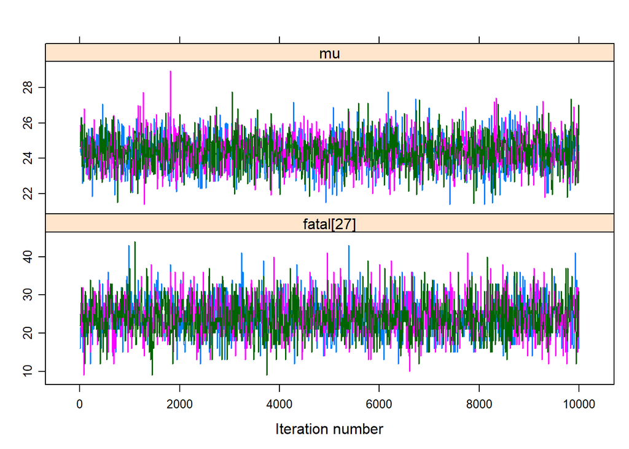

```r
print( xyplot( a1.res[,1:2] ) )
```

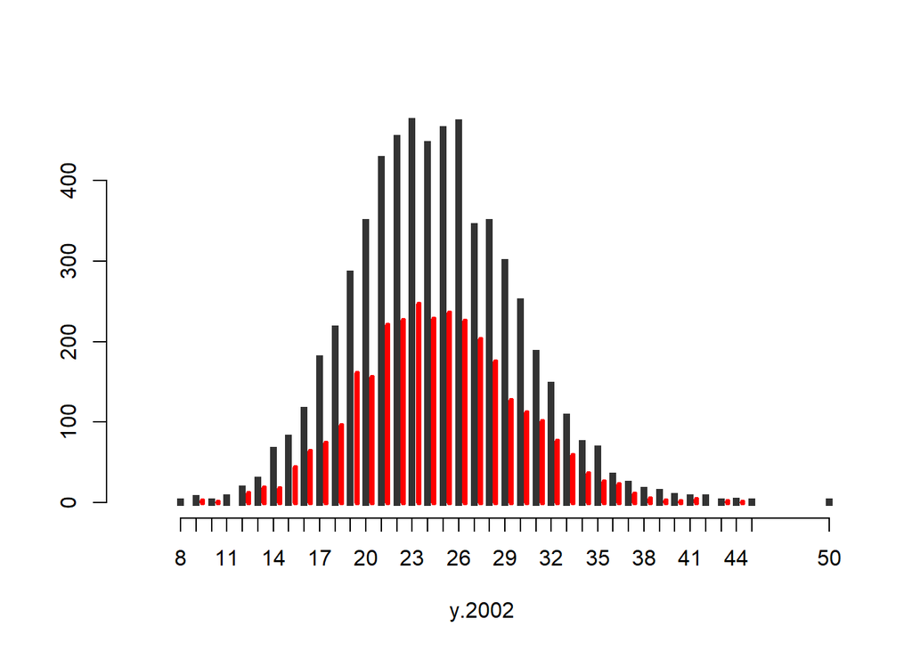

```r
theta <- rgamma(6000, 634, 26 )
y.2002 <- rpois(6000,theta)
plot( table(y.2002), type="h", lwd=5, lend=2, col=gray(0.2), bty="n", ylab="", xlim=c(5,50) )
tpr <- table( as.matrix( a1.res[,"fatal[27]"] ) )
points( as.numeric(names(tpr))+0.4, tpr, type="h", col="red", lwd=4 )
```

```r
###################
```

```r
result = ggs(a1.res)
ggs_density(result)
```

[output not shown]

```r
ggs_traceplot(result)
```

[output not shown]

```r
ggs_running(result)
```

[output not shown]

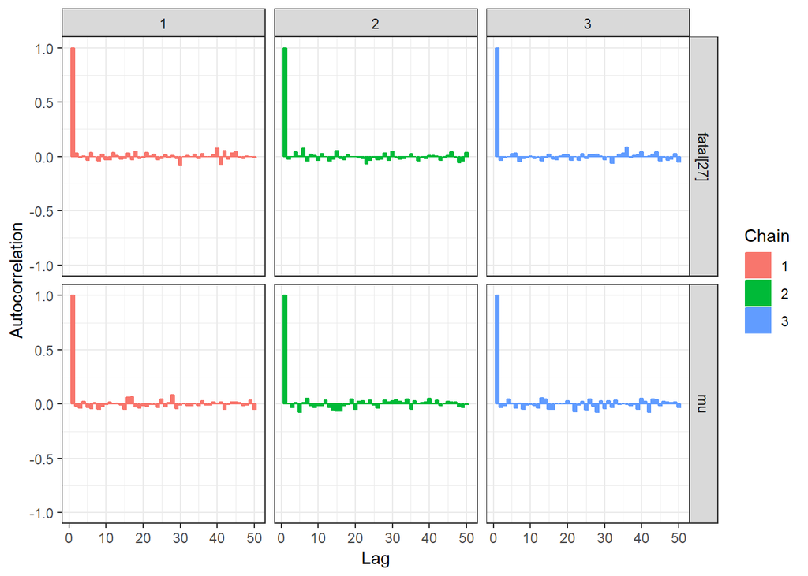

```r
ggs_autocorrelation(result)
```

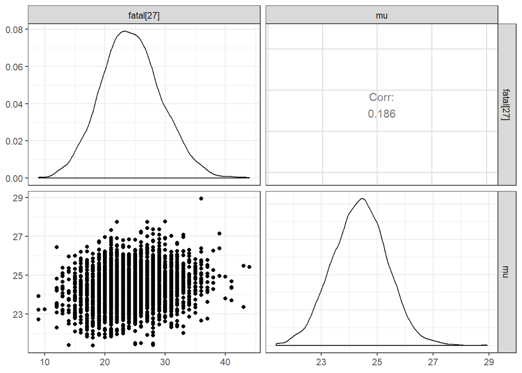

```r
ggs_pairs(result) ########mmmmmeh
```

## MODEL2

```r
a2.ini <- list( list( lambda=10 ),list( lambda=20 ),list( lambda=30 ) )
a2.dat <- list( fatal=c(airline$fatal,NA),miles=c(airline$miles,20), I=27 )
a2.par <- c("mu","fatal[27]")

# Model compilation and burn-in
a2.mod <- jags.model( file = "a2.jag",data = a2.dat,inits = a2.ini,n.chains = 3,n.adapt = 1000 )
# Sampling from the posterior
a2.res <- coda.samples( a2.mod,var = a2.par,n.iter = 10000,thin = 10 )
summary( a2.res )
```

```
##
## Iterations = 10:10000
## Thinning interval = 10
## Number of chains = 3
## Sample size per chain = 1000
##
## 1. Empirical mean and standard deviation for each variable,
##    plus standard error of the mean:
##
##             Mean     SD Naive SE Time-series SE
## fatal[27] 45.790 7.0579 0.128859       0.125003
## mu[1]      8.886 0.3534 0.006452       0.006454
## mu[2]      9.892 0.3934 0.007182       0.007184
## mu[3]     11.564 0.4599 0.008396       0.008399
## mu[4]     12.608 0.5014 0.009155       0.009157
## mu[5]     13.374 0.5319 0.009711       0.009714
## mu[6]     13.878 0.5519 0.010077       0.010079
## mu[7]     13.519 0.5377 0.009816       0.009819
## mu[8]     14.315 0.5693 0.010394       0.010397
## mu[9]     17.099 0.6800 0.012415       0.012418
## mu[10]    16.349 0.6502 0.011871       0.011874
## mu[11]    20.933 0.8325 0.015199       0.015203
## mu[12]    23.004 0.9148 0.016703       0.016707
## mu[13]    24.384 0.9697 0.017705       0.017710
## mu[14]    25.276 1.0052 0.018353       0.018358
## mu[15]    25.028 0.9953 0.018172       0.018177
## mu[16]    24.460 0.9727 0.017760       0.017765
## mu[17]    27.503 1.0938 0.019970       0.019975
## mu[18]    28.393 1.1292 0.020616       0.020622
## mu[19]    29.930 1.1903 0.021732       0.021738
## mu[20]    32.711 1.3009 0.023751       0.023757
## mu[21]    37.659 1.4977 0.027344       0.027351
## mu[22]    35.617 1.4164 0.025861       0.025868
## mu[23]    41.591 1.6540 0.030198       0.030206
## mu[24]    38.262 1.5217 0.027781       0.027789
## mu[25]    43.419 1.7268 0.031526       0.031535
## mu[26]    44.243 1.7595 0.032124       0.032133
## mu[27]    46.007 1.8297 0.033405       0.033414
##
## 2. Quantiles for each variable:
```

[output cut: 15 more lines]

```
## mu[13]    22.515 23.720 24.390 25.011 26.32
## mu[14]    23.339 24.588 25.282 25.927 27.28
## mu[15]    23.110 24.347 25.034 25.672 27.01
## mu[16]    22.585 23.794 24.466 25.089 26.40
## mu[17]    25.395 26.754 27.510 28.211 29.68
## mu[18]    26.217 27.620 28.400 29.124 30.64
## mu[19]    27.636 29.115 29.937 30.700 32.30
## mu[20]    30.204 31.821 32.719 33.553 35.30
## mu[21]    34.773 36.634 37.668 38.628 40.64
## mu[22]    32.886 34.647 35.625 36.533 38.44
## mu[23]    38.403 40.458 41.601 42.661 44.88
## mu[24]    35.329 37.220 38.271 39.246 41.29
## mu[25]    40.091 42.237 43.430 44.536 46.86
## mu[26]    40.852 43.038 44.254 45.381 47.75
## mu[27]    42.481 44.755 46.018 47.191 49.65
```

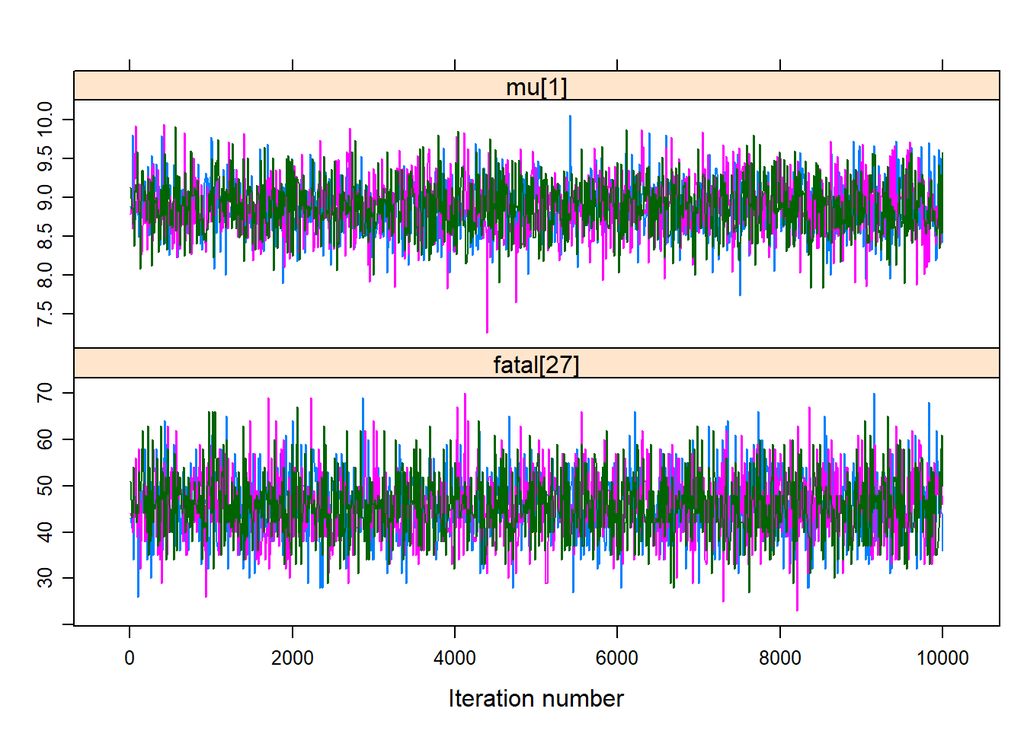

```r
print( xyplot( a2.res[,1:2] ) )
```

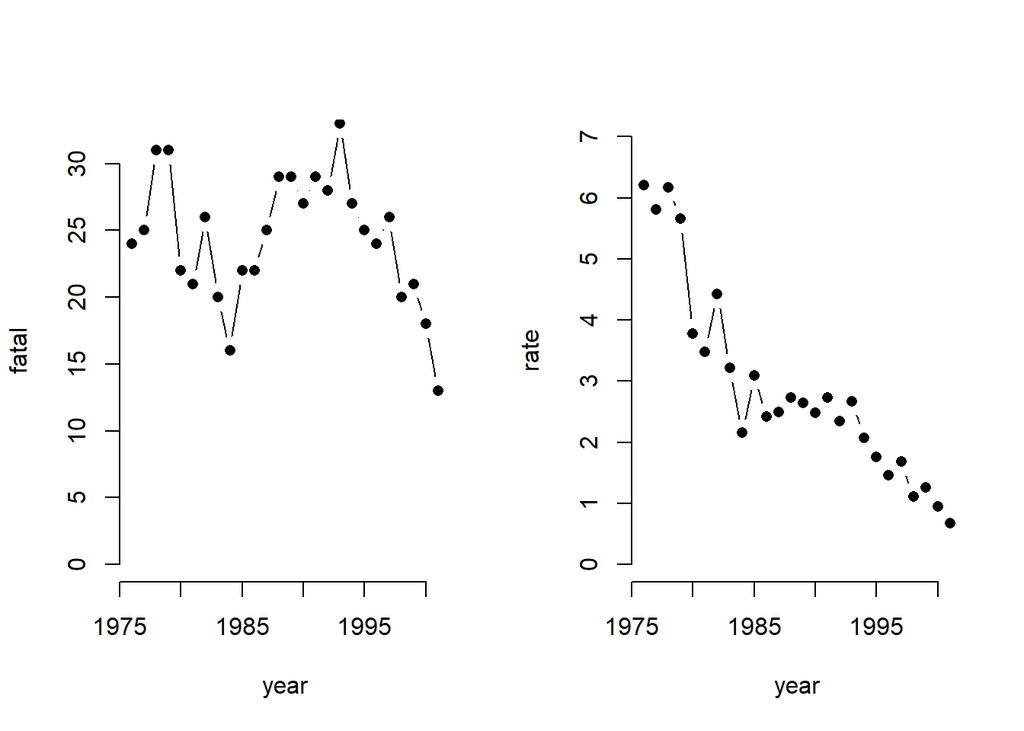

```r
 ################################
#A closer inspection of the number of fatal airline crashes can be dome by:
par(mfrow=c(1,2))
with(airline, plot( year, fatal, pch=16, type="b", ylim=c(0,32), bty="n" ) )
with(airline, plot( year, rate, pch=16, type="b", ylim=c(0,7), bty="n" ) )
```

```r
result2 = ggs(a2.res)
ggs_density(result)
```

[output not shown]

```r
ggs_traceplot(result)
```

[output not shown]

```r
ggs_running(result)
```

[output not shown]

[figure not shown]

```r
ggs_autocorrelation(result2)
```

## MODEL 3

```r
a3.ini <- list( list( alpha=10, beta=-0.5 ),list( alpha=20, beta=-0.6 ),list( alpha=30, beta=-0.4 ) )

a3.dat <- list( fatal=c(airline$fatal,NA),miles=c(airline$miles,20), I=27 )

a3.par <- c("alpha","beta","fatal[27]")

# Model compilation and burn-in
a3.mod <- jags.model( file = "a3.jag",data = a3.dat,inits = a3.ini,n.chains = 3,n.adapt = 1000 )
# Sampling from the posterior
a3.res <- coda.samples( a3.mod,var = a3.par,n.iter = 10000,thin = 10 )
summary( a3.res )
```

```
##
## Iterations = 1010:11000
## Thinning interval = 10
## Number of chains = 3
## Sample size per chain = 1000
##
## 1. Empirical mean and standard deviation for each variable,
##    plus standard error of the mean:
##
##              Mean      SD  Naive SE Time-series SE
## alpha      3.4247 0.15390 0.0028098      0.0032161
## beta      -0.1656 0.01337 0.0002441      0.0002897
## fatal[27] 12.2483 4.25190 0.0776288      0.0849713
##
## 2. Quantiles for each variable:
##
##              2.5%     25%     50%     75%   97.5%
## alpha      3.1327  3.3172  3.4237  3.5288  3.7375
## beta      -0.1922 -0.1747 -0.1657 -0.1565 -0.1387
## fatal[27]  5.0000  9.0000 12.0000 15.0000 21.0250
```

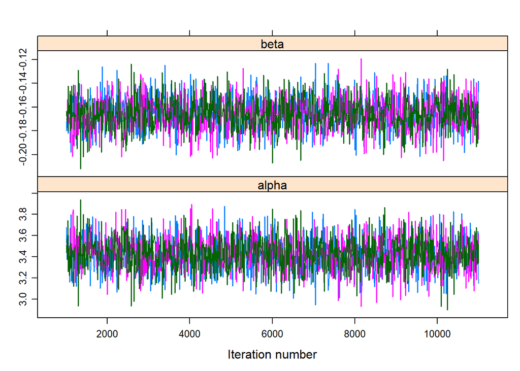

```r
print( xyplot( a3.res[,1:2] ) )
```

```r
result3 = ggs(a3.res)
ggs_density(result)
```

[output not shown]

```r
ggs_traceplot(result)
```

[output not shown]

```r
ggs_running(result)
```

[output not shown]

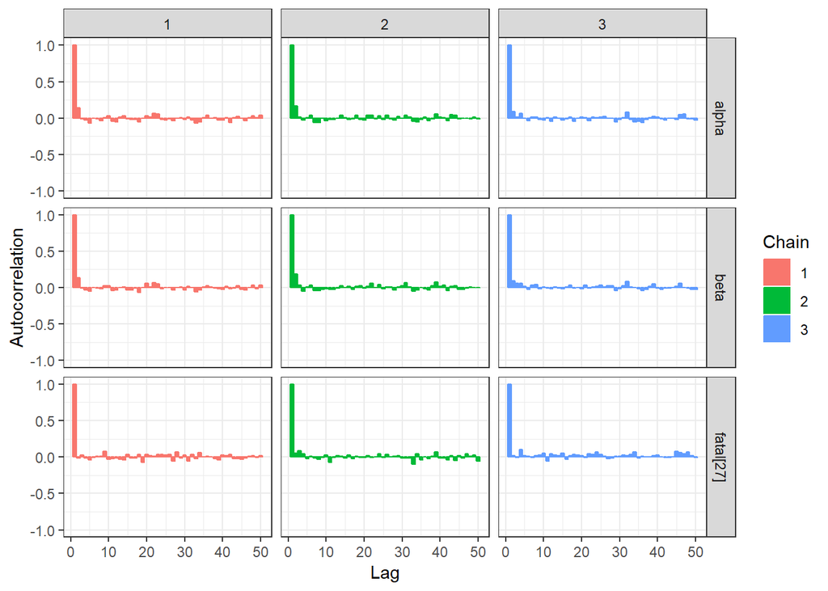

```r
ggs_autocorrelation(result3)
```